# AtlasVPM: Atlas de Farmacia

Variaciones en el consumo de **Antipsicóticos** por Zona Básica de Salud

Autor/a

Afiliaciones

[Atlas de Variaciones injustificadas de la Práctica Médica (Atlas VPM)](https://cienciadedatosysalud.org/)

Grupo de Ciencia de datos para la investigación en servicios y políticas sanitarias

Instituto Aragonés de Ciencias de la Salud (IACS)

Red de Investigación en Cronicidad, Atención Primaria y Prevención y Promoción de la Salud (RICAPPS)

Fecha de publicación

24 de noviembre de 2026

Versión de los análisis: 0.0.1

# Resumen ejecutivo

El número de envases de antipsicóticos dispensados en el periodo 2017-2024 aumentó un 44,4% (de 3,2 millones a 4,7 millones de dispensaciones). El 54,7% de todas estas dispensaciones se realizaron en mujeres. El porcentaje de mujeres con alguna dispensación de antipsicóticos fue mayor en mayores de 65 años. Las tarjetas sanitarias sin aseguramiento, farmacia gratuita y pensionistas y activos con rentas inferiores a 18000 euros (64,3% de la población en las CCAA analizadas) recibieron aproximadamente el 84,2% de los envases dispensados de antipsicóticos.

Con variación en la evolución anual y entre CCAA, en torno al 50% de los envases dispensados correspondieron a diazepinas, oxaxepinas y tiazepinas, el 22% a otros antipsicóticos, el 19% a benzamidas, el 4% a derivados de la butirofenona, y cerca del 5% otros (que incluye: fenotiazinas con cadena lateral alifática, derivados del indol, fenotiazinas con estructura piperazínica, fenotiazinas con estructura piperidínica, derivados del tioxanteno y derivados de difenilbutilpiperidina).

La mediana de consumo de antipsicóticos seleccionados en términos de DHD aumentó para el conjunto de ZBS pasando de 7,98 DHD en 2017 a 9,67 DHD en 2024 (aumento del 21,2%). Analizando por subgrupos, el aumento se produjo en diazepinas, oxaxepinas y tiazepinas, benzamidas, derivados del indol y otros antipsicóticos. Sin embargo, disminuyó en derivados de la butirofenona y en el resto se mantuvo estable.

Para el total de antipsicóticos, el consumo y variación de DHD fue mayor en el conjunto de TSI < 18000 euros, con una diferencia global de 3,9 veces en la mediana de consumo.

Para el conjunto de antipsicóticos analizados y años, la variación de DHD entre las ZBS de más y menos consumo, sin considerar las ZBS con valores extremos fue elevada, en torno a una razón de variación de 4,6 veces las DHD entre estas ZBS, siendo esta variación constante a lo largo de los años. Por subgrupos terapéuticos, esta variación fue todavía mayor, destacando la de benzamidas con una razón de variación de 8,2 entre las ZBS de más y menos consumo, diazepinas, oxaxepinas y tiazepinas con una razón de 5,6 y otros antipsicóticos con una razón de 4,9.

# Contexto

Este informe pertenece a la serie de informes de AtlasVPM sobre Farmacia, en el que se incluyen el análisis de consumo de Antidepresivos y de Antipsicóticos. En este informe nos referimos a consumo como la dispensación ambulatoria de un fármaco en oficina de farmacia a una persona con tarjeta sanitaria en el Sistema Nacional de Salud (SNS). El consumo de los medicamentos está mediado por la prescripción de un profesional sanitario -principalmente los médicos especialistas en medicina familiar y comunitaria- y, en el caso de algunos medicamentos, al visado de la receta médica por un inspector del SNS. La utilización de los medicamentos, como sucede con otras tecnologías sanitarias, está sujeta a una gran variabilidad. El análisis de las *variaciones en la práctica médica*, entendidas como las variaciones sistemáticas -no aleatorias- en las tasas estandarizadas de una exposición o intervención sanitaria (i.e., consumo de medicamento) al nivel que se produce la toma de decisiones sobre esta exposición o intervención sanitaria, en este caso, a nivel de Zona Básica de Salud (ZBS), es indispensable para identificar potenciales problemas de gestión sanitaria y ayudar a orientar la toma de decisiones sobre los servicios de salud. Las variaciones sistemáticas en los patrones de dispensación de medicamentos antidepresivos y antipsicóticos suponen un desafío importante para todos los Sistemas de Salud.

**Atención**

Debe tenerse en cuenta que, cuando se habla de grupos mayores (‘N05AA’,‘N05AB’,‘N05AC’,‘N05AD’,‘N05AE’,‘N05AF’,‘N05AH’,‘N05AG’,‘N05AL’,‘N05AX’) o total (N05A) de Antipsicóticos en este estudio, estos ATC no incluyen todos los antipsicóticos sino sólo aquellos seleccionados como relevantes para estudio que aparecen en Sección 4.3 (para más información descargar el fichero ([Modelo de datos](https://github.com/cienciadedatosysalud/atlas-farmacia/blob/main/atlas_antipsicoticos/docs/CDM/common_datamodel.xlsx))

# Resultados

En este estudio participan un total de 8 comunidades autónomas, con una población global de 16,312,282 en el año 2024, de la cual, la media mensual de personas distintas que han sido dispensadas de algún antipsicótico (ATC = N05A) durante el periodo de estudio 2017 a 2024 es de un 1.59%.

**Descripción tabla**

La siguiente tabla muestra el número de envases totales por año, la aportación al mismo por cada comunidad autónoma, sexo y para el conjunto específico de categorías TSI (0,1,2, y 4).

Tabla descriptiva anual: Nº envases (%)

Antipsicóticos (N05A)

|  | 2017 | 2018 | 2019 | 2020 | 2021 | 2022 | 2023 | 2024 |
| --- | --- | --- | --- | --- | --- | --- | --- | --- |
| Total Nº envases anual |  |  |  |  |  |  |  |  |
| Nº envases | 3226059 | 3424468 | 3623104 | 3840947 | 4077170 | 4264385 | 4441192 | 4659998 |
| CCAA |  |  |  |  |  |  |  |  |
| Asturias | 351198 (10.89%) | 365302 (10.67%) | 384141 (10.6%) | 404493 (10.53%) | 430129 (10.55%) | 450606 (10.57%) | 465426 (10.48%) | 482452 (10.35%) |
| País Vasco | 565057 (17.52%) | 612325 (17.88%) | 640788 (17.69%) | 675430 (17.58%) | 693190 (17%) | 704976 (16.53%) | 741948 (16.71%) | 771681 (16.56%) |
| Navarra | 62956 (1.95%) | 67462 (1.97%) | 72688 (2.01%) | 80120 (2.09%) | 87567 (2.15%) | 94163 (2.21%) | 103229 (2.32%) | 112702 (2.42%) |
| La Rioja | 44328 (1.37%) | 45581 (1.33%) | 48405 (1.34%) | 54732 (1.42%) | 59172 (1.45%) | 61314 (1.44%) | 63342 (1.43%) | 63592 (1.36%) |
| Aragón | 278226 (8.62%) | 294172 (8.59%) | 306544 (8.46%) | 330935 (8.62%) | 351042 (8.61%) | 360822 (8.46%) | 371253 (8.36%) | 387574 (8.32%) |
| Madrid | 881547 (27.33%) | 951311 (27.78%) | 1020075 (28.15%) | 1046652 (27.25%) | 1117989 (27.42%) | 1196891 (28.07%) | 1260546 (28.38%) | 1345394 (28.87%) |
| Castilla y León | 649704 (20.14%) | 675008 (19.71%) | 706050 (19.49%) | 745882 (19.42%) | 780489 (19.14%) | 801544 (18.8%) | 811026 (18.26%) | 833690 (17.89%) |
| Región de Murcia | 393043 (12.18%) | 413307 (12.07%) | 444413 (12.27%) | 502703 (13.09%) | 557592 (13.68%) | 594069 (13.93%) | 624422 (14.06%) | 662913 (14.23%) |
| Sexo |  |  |  |  |  |  |  |  |
| Hombres | 1487662 (46.11%) | 1570654 (45.87%) | 1653719 (45.64%) | 1748370 (45.52%) | 1838954 (45.1%) | 1913501 (44.87%) | 1990159 (44.81%) | 2090985 (44.87%) |
| Mujeres | 1738397 (53.89%) | 1853814 (54.13%) | 1969385 (54.36%) | 2092577 (54.48%) | 2238216 (54.9%) | 2350884 (55.13%) | 2451033 (55.19%) | 2569013 (55.13%) |
| Conjunto categorías TSI < 18.000 € (Categorías 0, 1, 2, 4) |  |  |  |  |  |  |  |  |
| Conjunto categorías TSI < 18.000 € (Categorías 0, 1, 2, 4) | 2773764 (85.98%) | 2949138 (86.12%) | 3129476 (86.38%) | 3228096 (84.04%) | 3445463 (84.51%) | 3588824 (84.16%) | 3662745 (82.47%) | 3780362 (81.12%) |

## Porcentaje de envases dispensados por subgrupo terapéutico

**Descripción figura**

Para el total de envases dispensados (suma de todas las comunidades autónomas participantes) en toda la serie temporal, se muestra el porcentaje de envases por cada subgrupo terapéutico.

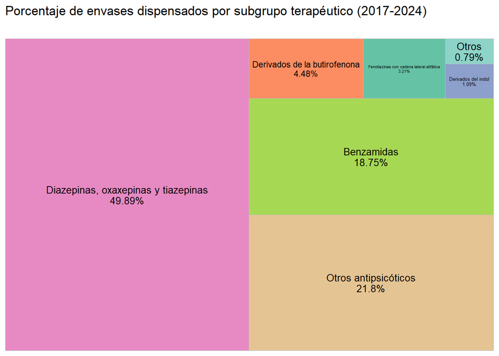

**N.B.: En esta figura, la categoría “otros” engloba: N05AB, N05AC, N05AF, N05AG.**

## Evolución temporal del porcentaje de envases dispensados por subgrupo terapéutico

**Descripción figura**

Para el total de envases dispensados en toda la serie temporal en cada comunidad autónoma, se muestra el porcentaje de envases por cada subgrupo terapéutico.

La leyenda es, de acuerdo con la figura anterior:

- Fenotiazinas con cadena lateral alifática (N05AA),
- Derivados de la butirofenona (N05AD),
- Derivados del indol (N05AE),
- Diazepinas, oxaxepinas y tiazepinas (N05AH),
- Benzamidas (N05AL),
- Otros antipsicóticos (N05AX),
- Otros (incluye: N05AB, N05AC, N05AF, N05AG).

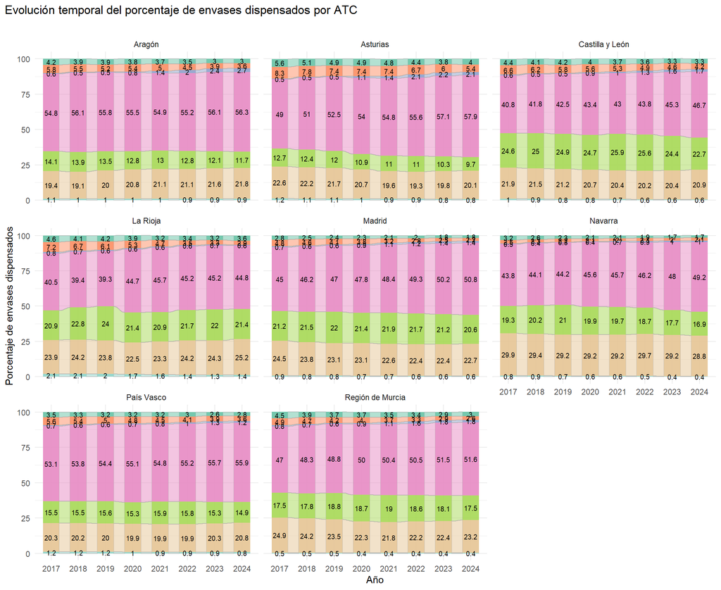

**N.B.: En estas figuras, la categoría “otros” engloba: N05AB, N05AC, N05AF, N05AG.**

## Evolución temporal del porcentaje de envases dispensados por generación

**Descripción figura**

Para el total de envases dispensados en toda la serie temporal en cada comunidad autónoma, se muestra el porcentaje de envases por cada subgrupo terapéutico.

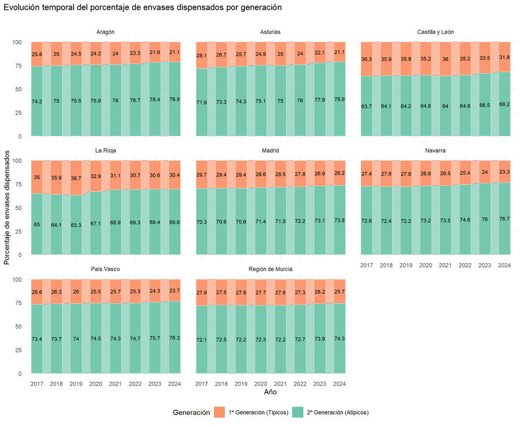

## Distribución de la población con alguna dispensación de antipsicóticos (*N05A*) por grupo de edad y sexo

**Descripción figura**

Se muestra la distribución de la población con dispensaciones por grupo quinquenal de edad y sexo en toda la serie temporal.

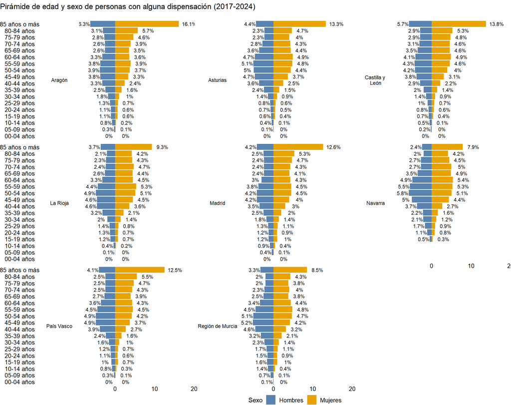

## Porcentaje de población con alguna dispensación de antipsicóticos (*N05A*) en cada mes para el conjunto de la serie temporal y por sexo

**Descripción figura**

Se muestra la distribución de la población con dispensaciones por sexo y mes en toda la serie temporal. Se construye calculando el porcentaje de personas con alguna dispensación por sexo para cada mes de cada año y luego realizando la media de cada mes a lo largo de la serie temporal.

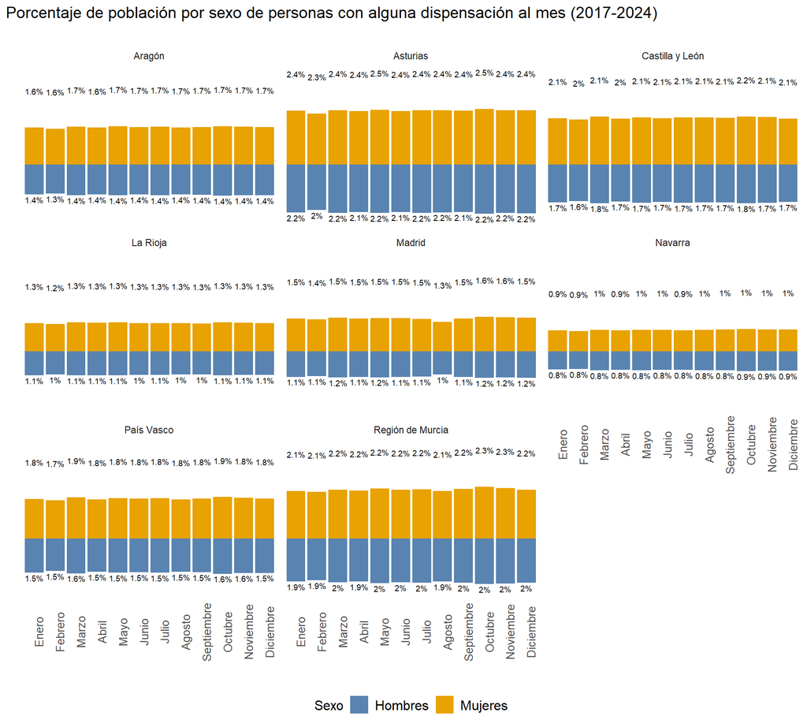

## Evolución de la variación de consumo por ZBS (SNS)

**Descripción figura**

Se muestra la variación (mediante violines) del consumo (DHD) en las zonas básicas de salud que componen el sistema nacional de salud de manera que cada punto es una zona básica. Las líneas discontinuas negras son la mediana (P50) anual y la línea discontinua roja (P50 global) es la mediana de toda la serie temporal.

**Antipsicóticos (N05A)**

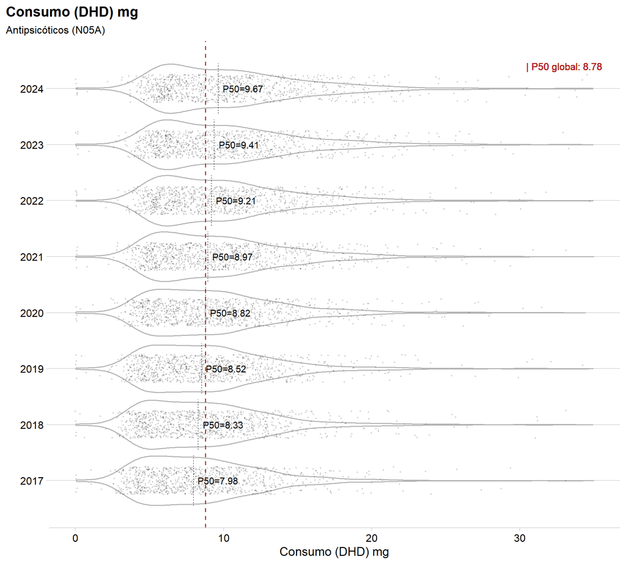

**Fenotiazinas con cadena lateral alifática (N05AA)**

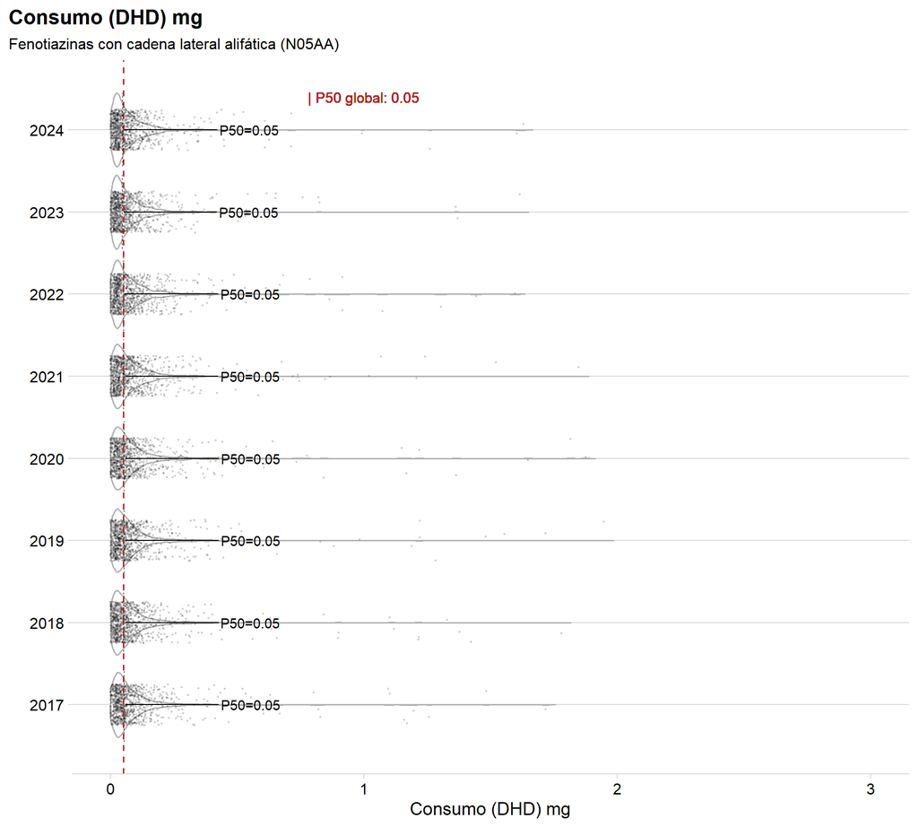

**Fenotiazinas con estructura piperazínica (N05AB)**

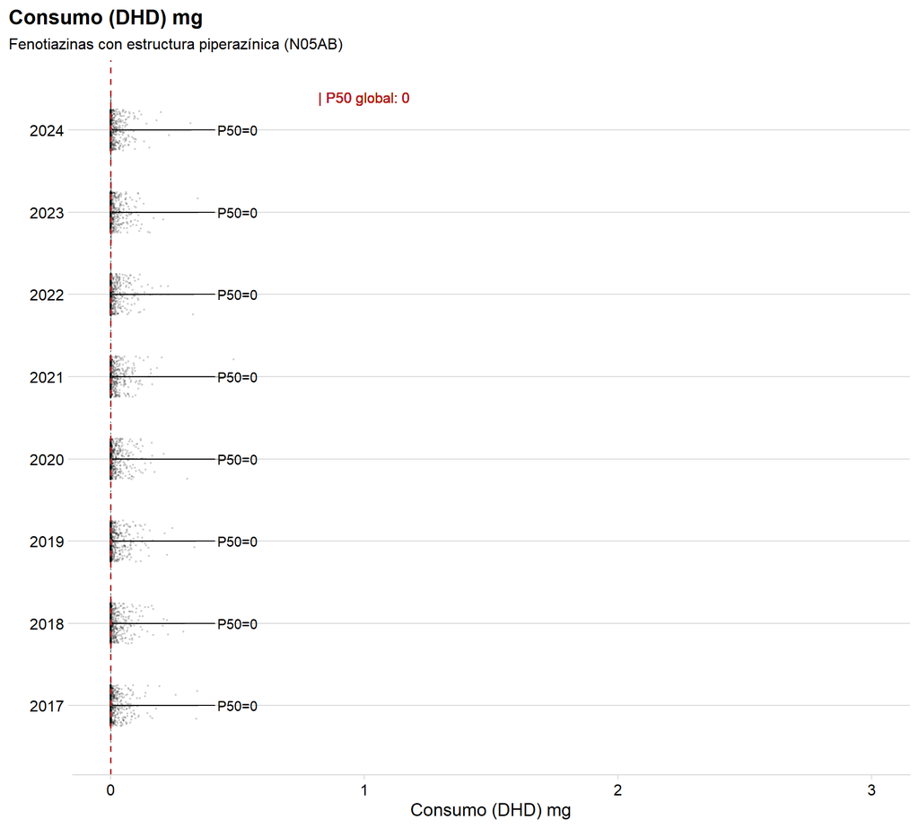

**Fenotiazinas con estructura piperidínica (N05AC)**

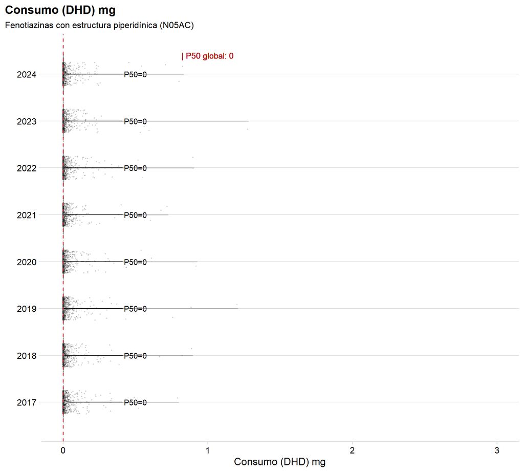

**Derivados de la butirofenona (N05AD)**

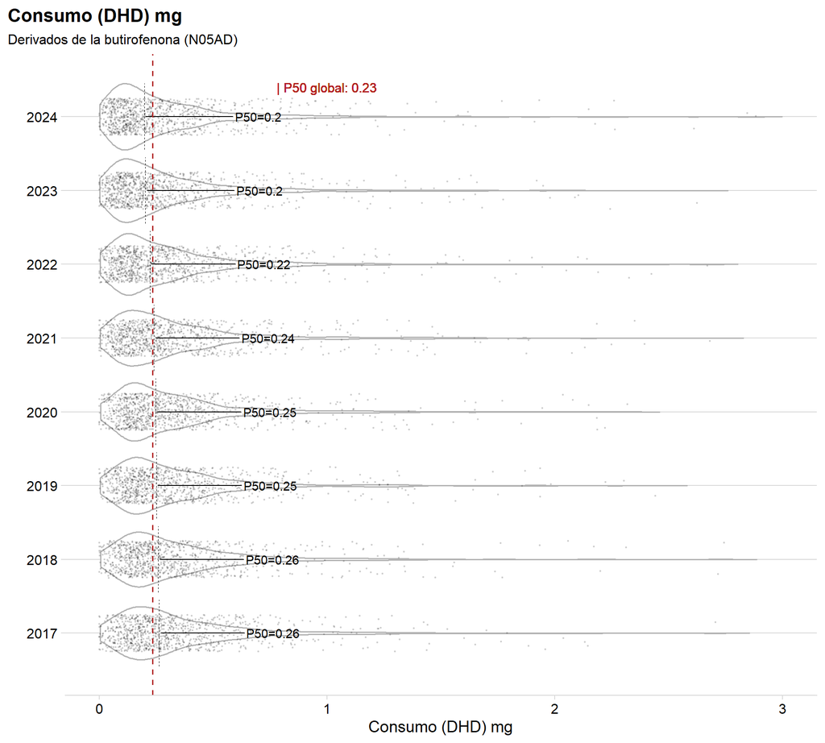

**Derivados del indol (N05AE)**

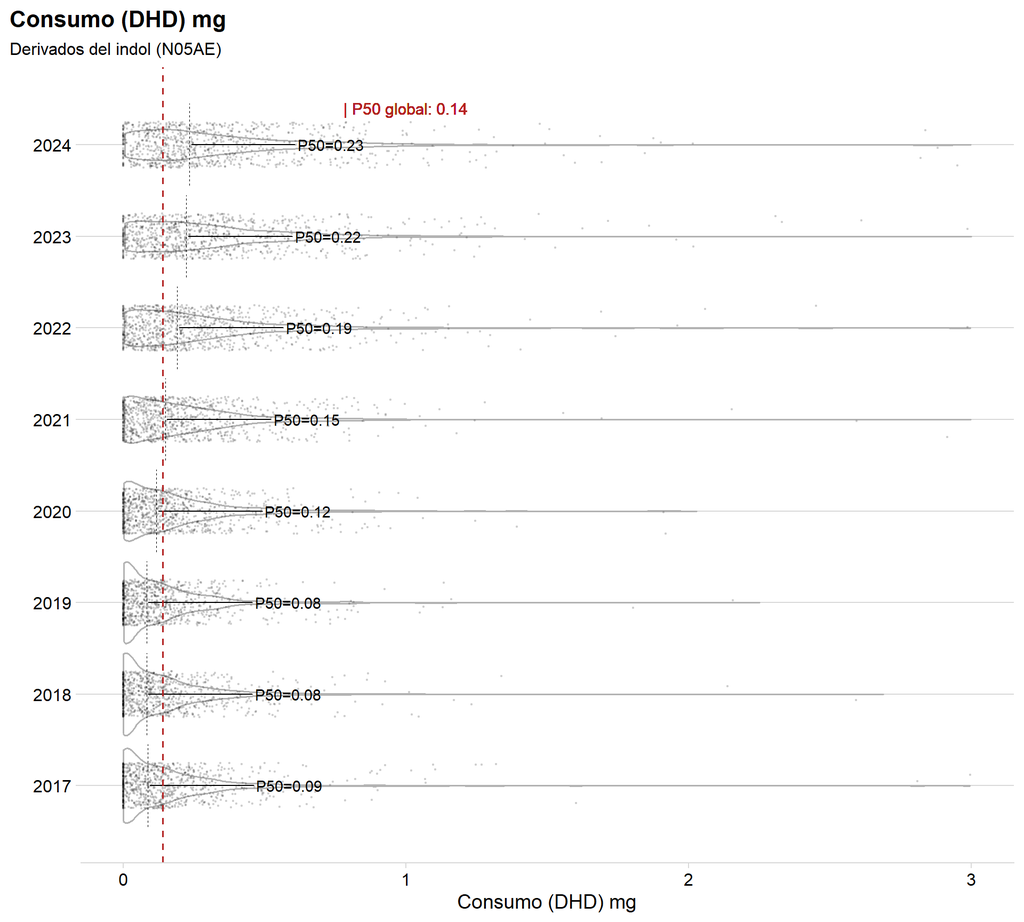

**Derivados del tioxanteno (N05AF)**

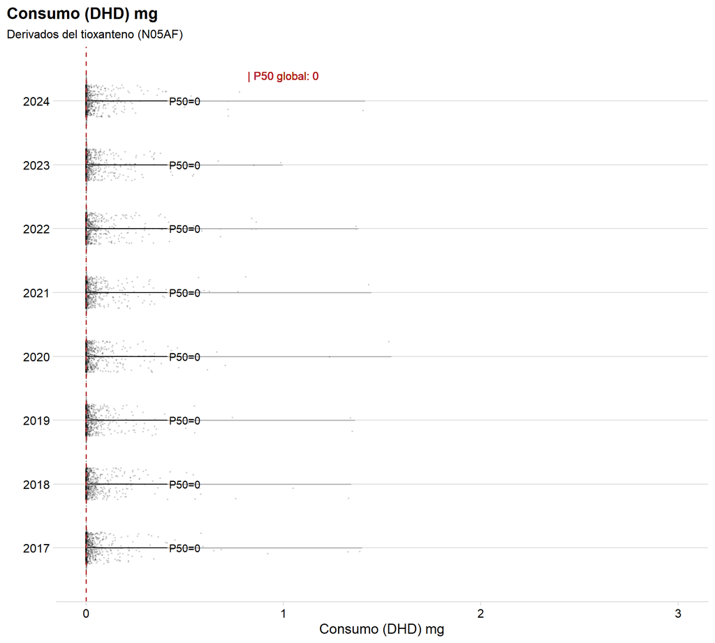

**Derivados del difenilbutilpiperidina (N05AG)**

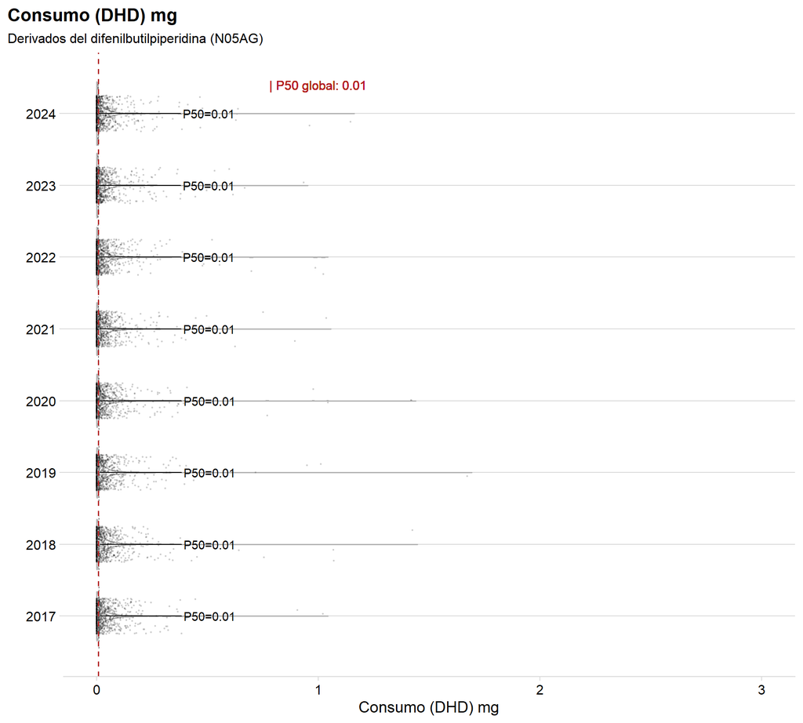

**Diazepinas, oxaxepinas y tiazepinas (N05AH)**

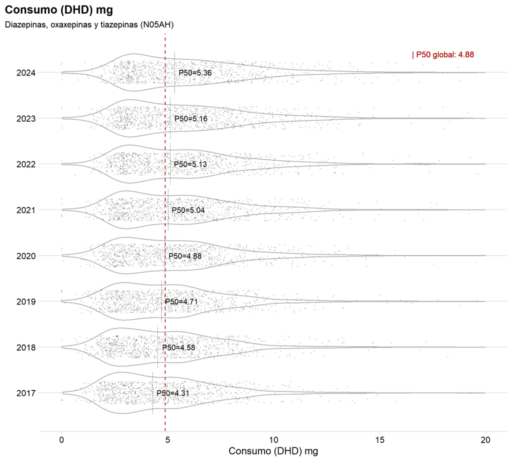

**Benzamidas (N05AL)**

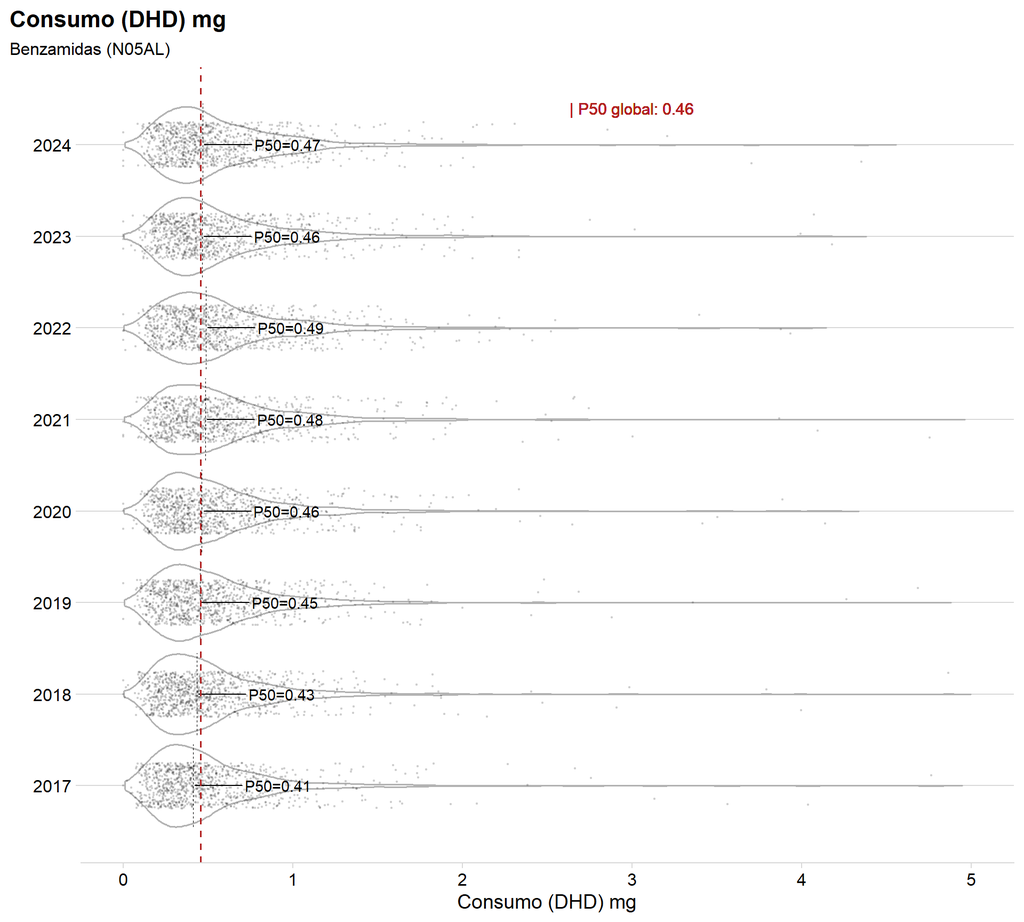

**Otros antipsicóticos (N05AX)**

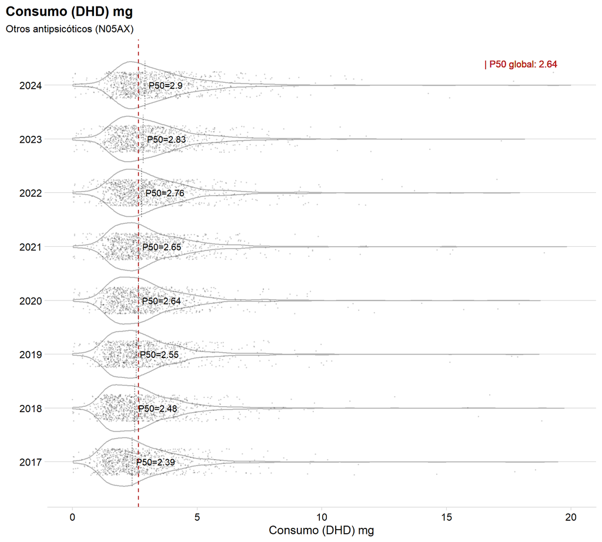

## Evolución de la variación de consumo por ZBS y TSI (SNS)

**Descripción figura**

Se muestra la variación (mediante violines) del consumo (DHD) en las zonas básicas de salud que componen el sistema nacional de salud de manera que cada punto es una zona básica. Las líneas discontinuas negras son la mediana (P50) anual y la línea discontinua roja (P50 global) es la mediana de toda la serie temporal. Se comparan: categorías TSI < 18.000 € vs categorías TSI >= 18.000 €.

**Antipsicóticos (N05A)**

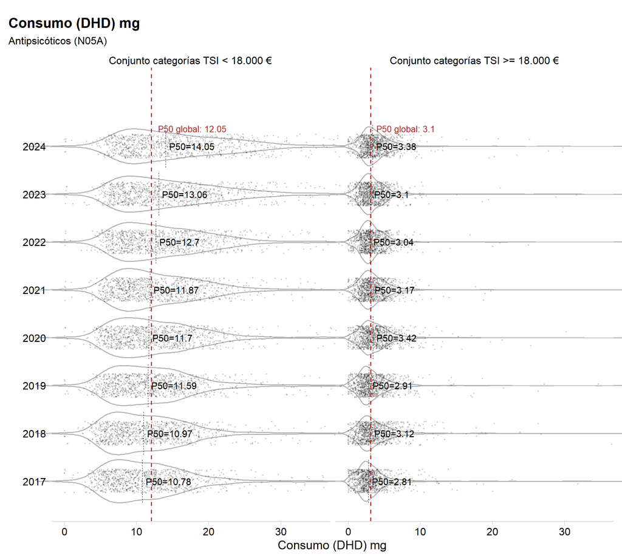

**Fenotiazinas con cadena lateral alifática (N05AA)**

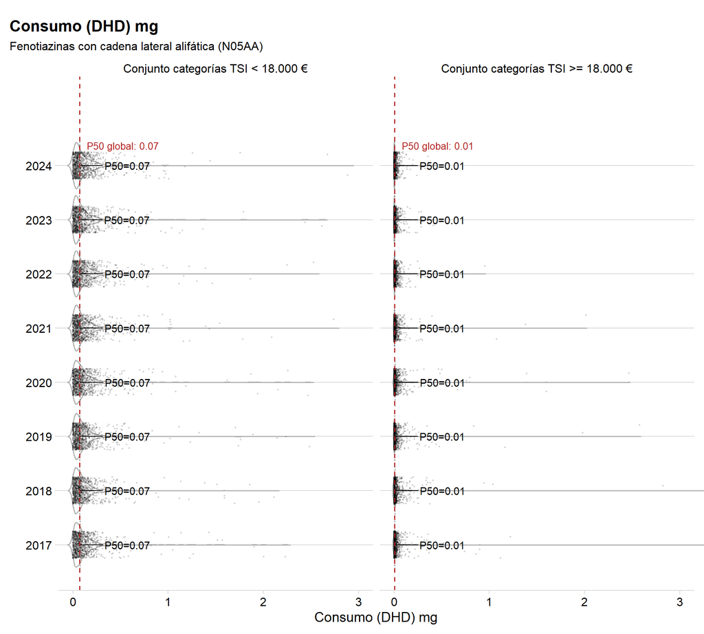

**Fenotiazinas con estructura piperazínica (N05AB)**

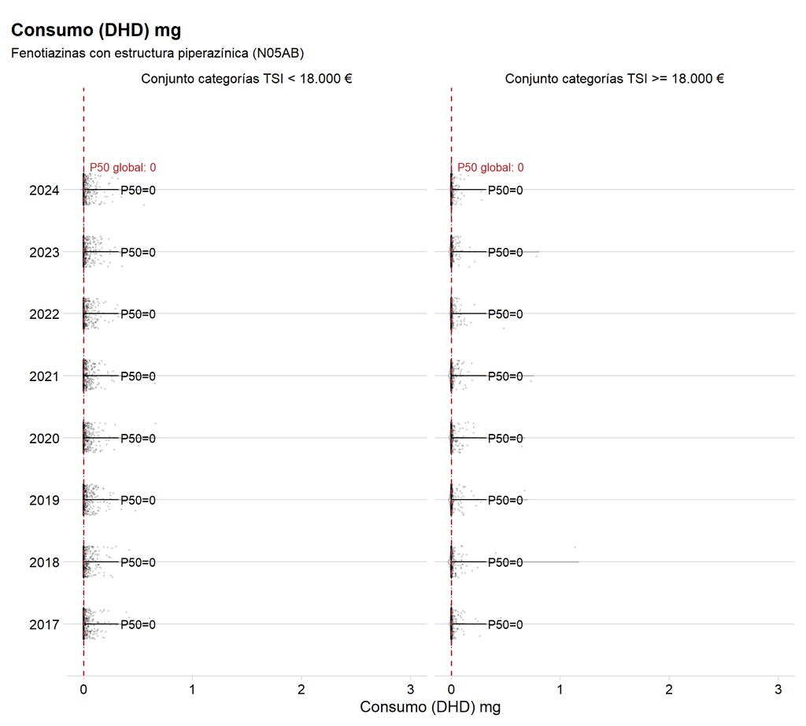

**Fenotiazinas con estructura piperidínica (N05AC)**

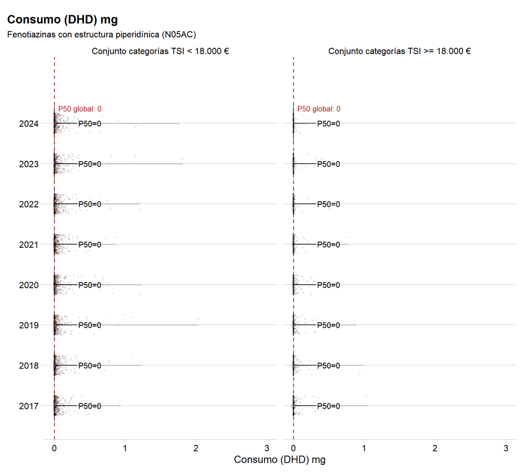

**Derivados de la butirofenona (N05AD)**

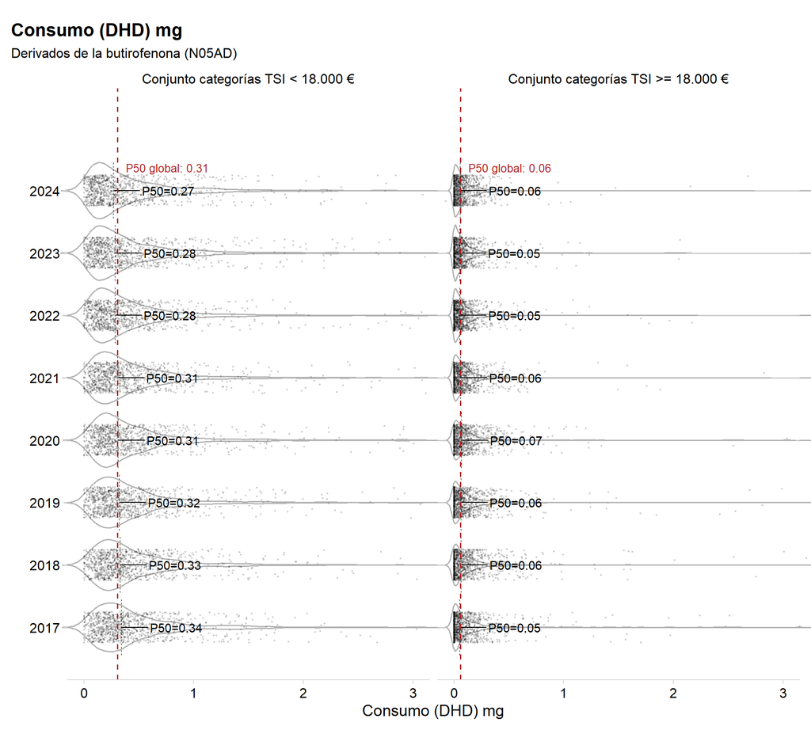

**Derivados del indol (N05AE)**

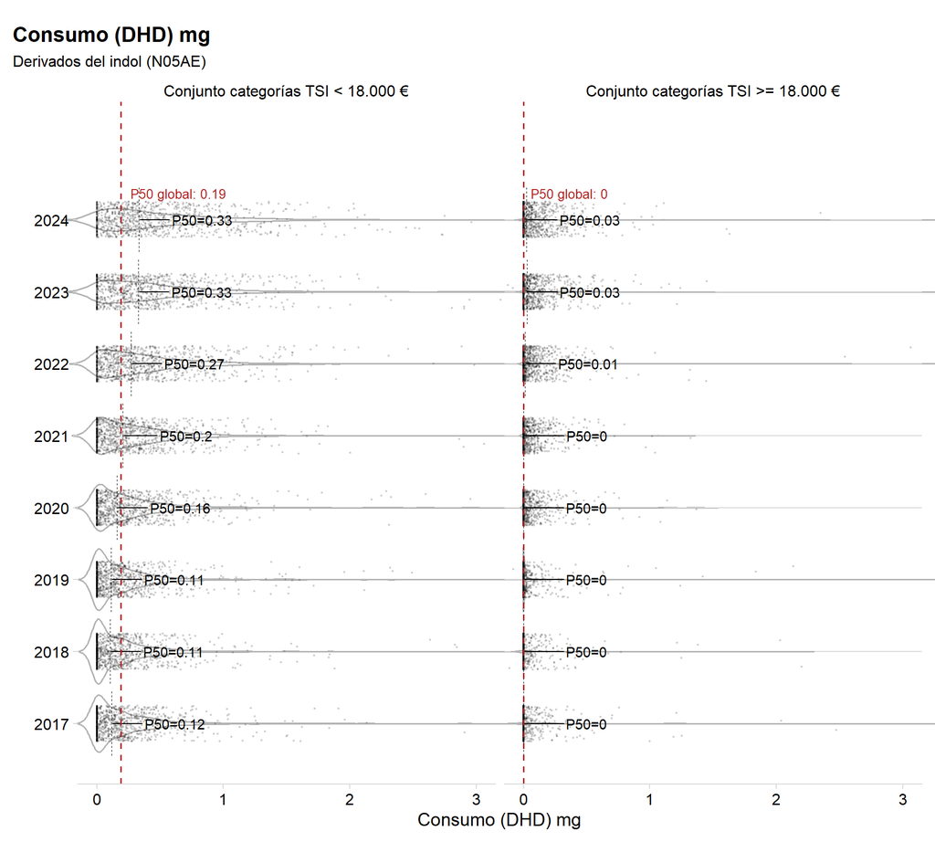

**Derivados del tioxanteno (N05AF)**

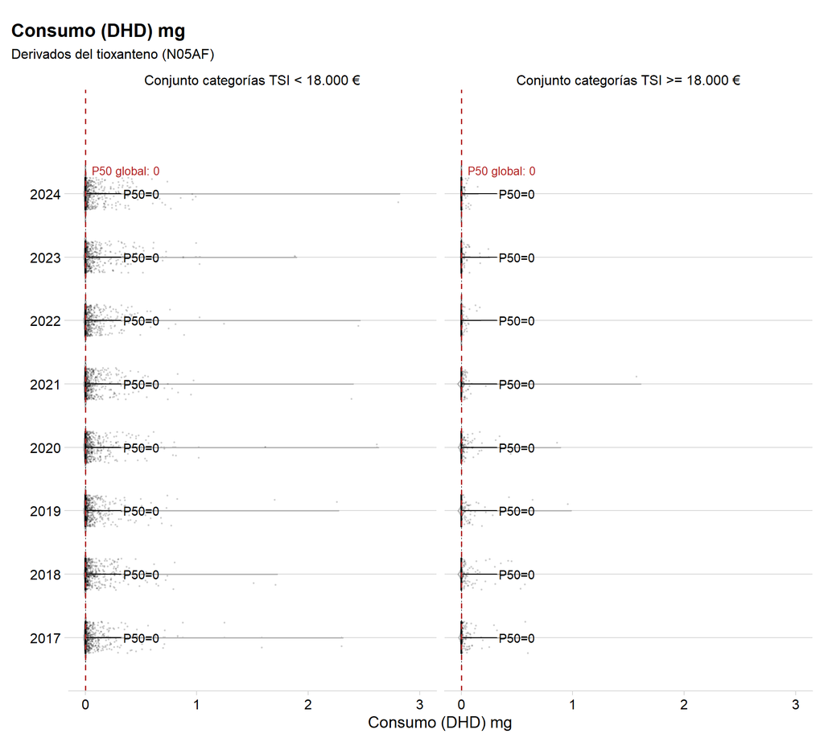

**Derivados del difenilbutilpiperidina (N05AG)**

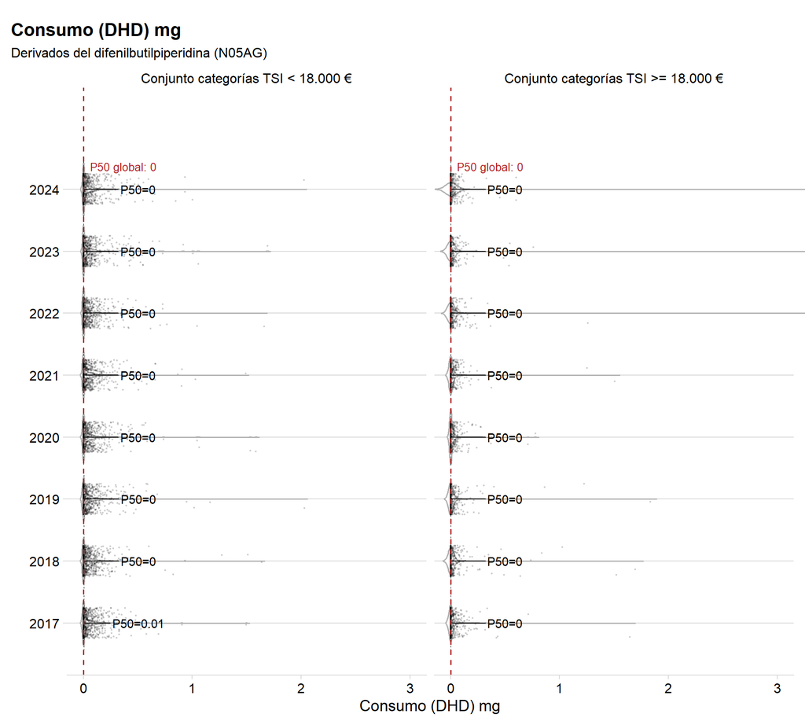

**Diazepinas, oxaxepinas y tiazepinas (N05AH)**

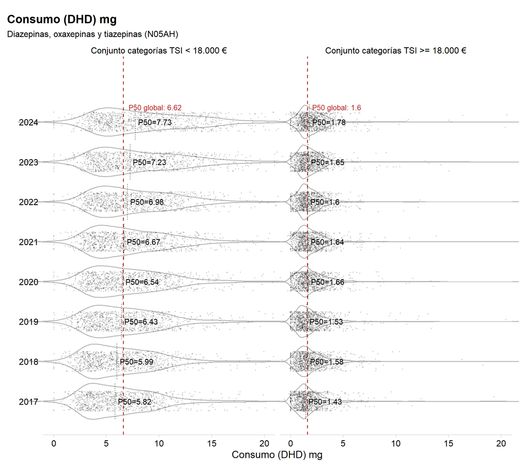

**Benzamidas (N05AL)**

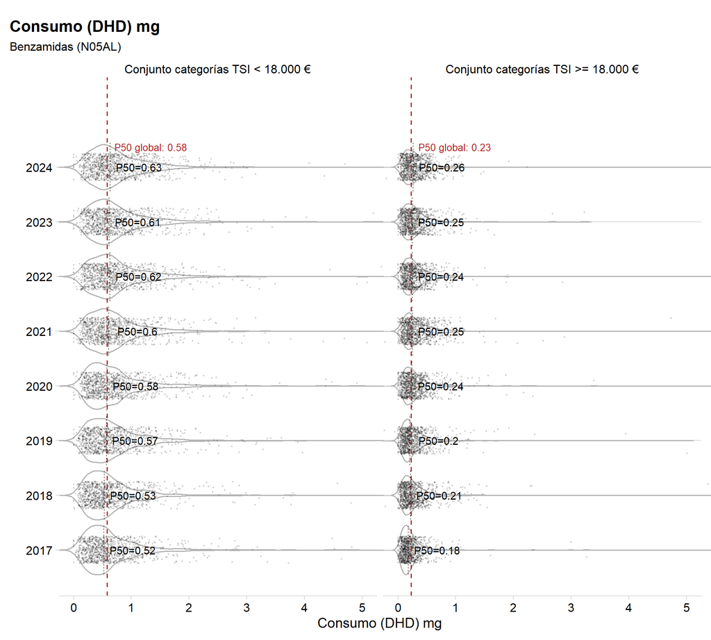

**Otros antipsicóticos (N05AX)**

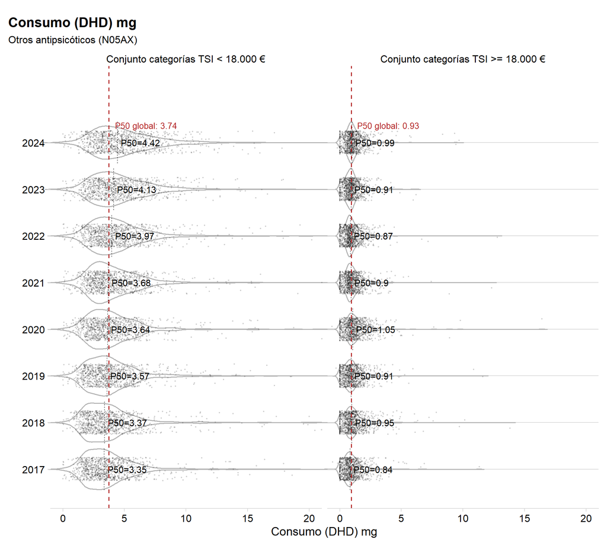

## Evolución de la variación de consumo (DHD) por ZBS y por CCAA

**Descripción figura**

Se muestra la evolución de la variación por CCAA del consumo (DHD) en las zonas básicas de salud que componen el sistema nacional de salud de manera que cada punto es una zona básica. La línea sólida roja es la mediana nacional y la zona sobreada gris es el rango intercuartílico, por lo que son comunes a todas las comunidades.

**Antipsicóticos (N05A)**

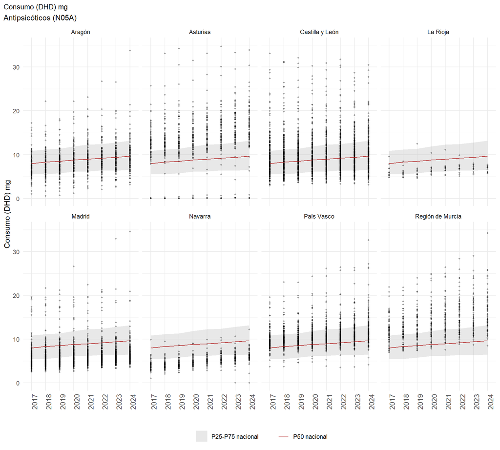

**Fenotiazinas con cadena lateral alifática (N05AA)**

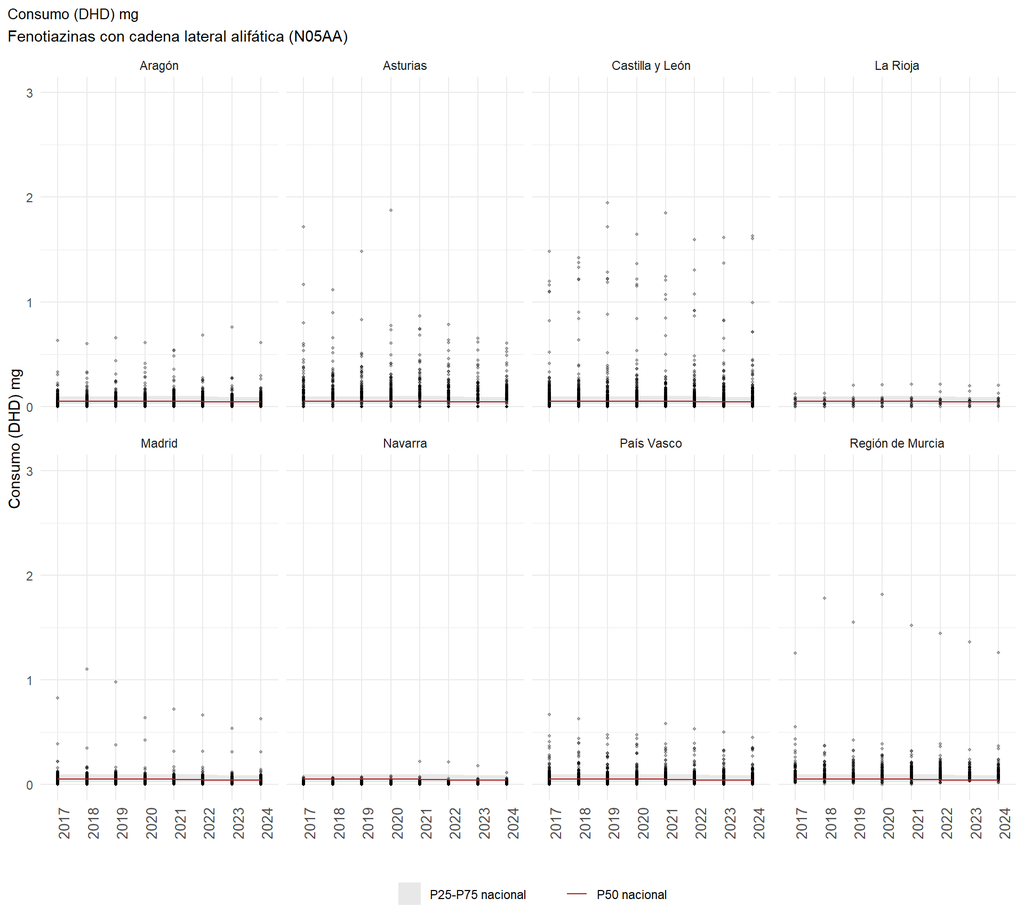

**Fenotiazinas con estructura piperazínica (N05AB)**

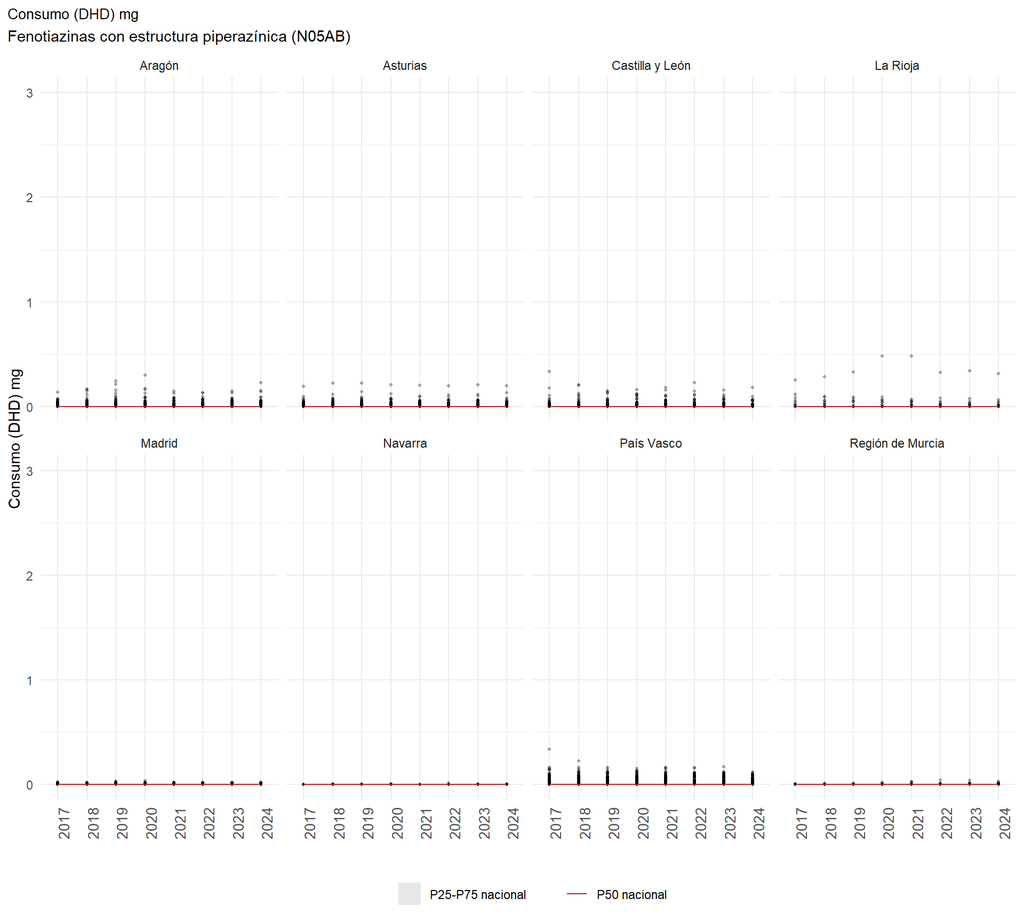